# cdcdata-exercise – Rebecca Basta Data Analysis Portfolio

This dataset comes from CDC’s Smoking-Attributable Mortality, Morbidity, and Economic Costs (SAMMEC). It looks at estimates of smoking-attributable health costs (millions of dollars)catergorized by states during the years of 2005-2009.

Link to the source: https://data.cdc.gov/Health-Consequences-and-Costs/Smoking-Attributable-Mortality-Morbidity-and-Econo/ezab-8sq5/about_data

```r
library(tidyverse)
library(ggplot2)

# File path (your uploaded CSV in this workspace)
file_path <- "sae.csv"

## Read the data
sae_raw <- read.csv(file_path, stringsAsFactors = FALSE)

## Select variables that I will be using
sae_clean <- sae_raw %>%
  select(Year, LocationDesc, MeasureDesc, Data_Value, Data_Value_Unit)

## Clean Data_Value
sae_raw$Data_Value <- as.numeric(gsub(",", "", sae_raw$Data_Value))

## Variables
sae <- sae_raw[, c(
  "Year",
  "LocationAbbr",
  "LocationDesc",
  "TopicDesc",
  "MeasureDesc",
  "Variable",
  "Data_Value",
  "Data_Value_Type",
  "Data_Value_Unit"
)]

## Summary
summary(sae)
```

```
      Year      LocationAbbr       LocationDesc        TopicDesc
 Min.   :2005   Length:1560        Length:1560        Length:1560
 1st Qu.:2006   Class :character   Class :character   Class :character
 Median :2007   Mode  :character   Mode  :character   Mode  :character
 Mean   :2007
 3rd Qu.:2008
 Max.   :2009
 MeasureDesc          Variable           Data_Value       Data_Value_Type
 Length:1560        Length:1560        Min.   :     8.4   Length:1560
 Class :character   Class :character   1st Qu.:   105.7   Class :character
 Mode  :character   Mode  :character   Median :   306.1   Mode  :character
                                       Mean   :  1545.2
                                       3rd Qu.:   842.3
                                       Max.   :132459.8
 Data_Value_Unit
 Length:1560
 Class :character
 Mode  :character
```

```r
anyNA(sae$Data_Value)   # check missing numeric values
```

```
[1] FALSE
```

```r
## Data after cleaning
head(sae, 10)
```

```
   Year LocationAbbr  LocationDesc                                TopicDesc
1  2009           RI  Rhode Island Smoking-Attributable Expenditures (SAEs)
2  2007           SD  South Dakota Smoking-Attributable Expenditures (SAEs)
3  2009           NH New Hampshire Smoking-Attributable Expenditures (SAEs)
4  2006           MD      Maryland Smoking-Attributable Expenditures (SAEs)
5  2009           LA     Louisiana Smoking-Attributable Expenditures (SAEs)
6  2006           TN     Tennessee Smoking-Attributable Expenditures (SAEs)
7  2005           WI     Wisconsin Smoking-Attributable Expenditures (SAEs)
8  2005           LA     Louisiana Smoking-Attributable Expenditures (SAEs)
9  2007           MO      Missouri Smoking-Attributable Expenditures (SAEs)
10 2008           TX         Texas Smoking-Attributable Expenditures (SAEs)
       MeasureDesc           Variable Data_Value     Data_Value_Type
1  Type of Expense              Other       47.2 Millions of Dollars
2  Type of Expense       Nursing Home       29.2 Millions of Dollars
3  Type of Expense              Other       41.4 Millions of Dollars
```

[output cut: 18 more lines]

```r
##Summarize data
str(sae)
```

```
'data.frame':   1560 obs. of  9 variables:
 $ Year           : int  2009 2007 2009 2006 2009 2006 2005 2005 2007 2008 ...
 $ LocationAbbr   : chr  "RI" "SD" "NH" "MD" ...
 $ LocationDesc   : chr  "Rhode Island" "South Dakota" "New Hampshire" "Maryland" ...
 $ TopicDesc      : chr  "Smoking-Attributable Expenditures (SAEs)" "Smoking-Attributable Expenditures (SAEs)" "Smoking-Attributable Expenditures (SAEs)" "Smoking-Attributable Expenditures (SAEs)" ...
 $ MeasureDesc    : chr  "Type of Expense" "Type of Expense" "Type of Expense" "Type of Expense" ...
 $ Variable       : chr  "Other" "Nursing Home" "Other" "Prescription Drugs" ...
 $ Data_Value     : num  47.2 29.2 41.4 465.2 117.5 ...
 $ Data_Value_Type: chr  "Millions of Dollars" "Millions of Dollars" "Millions of Dollars" "Millions of Dollars" ...
 $ Data_Value_Unit: chr  "$" "$" "$" "$" ...
```

```r
summary(sae)
```

```
      Year      LocationAbbr       LocationDesc        TopicDesc
 Min.   :2005   Length:1560        Length:1560        Length:1560
 1st Qu.:2006   Class :character   Class :character   Class :character
 Median :2007   Mode  :character   Mode  :character   Mode  :character
 Mean   :2007
 3rd Qu.:2008
 Max.   :2009
 MeasureDesc          Variable           Data_Value       Data_Value_Type
 Length:1560        Length:1560        Min.   :     8.4   Length:1560
 Class :character   Class :character   1st Qu.:   105.7   Class :character
 Mode  :character   Mode  :character   Median :   306.1   Mode  :character
                                       Mean   :  1545.2
                                       3rd Qu.:   842.3
                                       Max.   :132459.8
 Data_Value_Unit
 Length:1560
 Class :character
 Mode  :character
```

```r
## Distribution by year
sae %>%
  count(Year) %>%
  mutate(percent = n / sum(n) * 100)
```

```
  Year   n percent
1 2005 312      20
2 2006 312      20
3 2007 312      20
4 2008 312      20
5 2009 312      20
```

```r
## Distrubution by state
sae %>%
  count(LocationDesc) %>%
  mutate(percent = n / sum(n) * 100) %>%
  arrange(desc(percent))
```

```
           LocationDesc  n  percent
1               Alabama 30 1.923077
2                Alaska 30 1.923077
3               Arizona 30 1.923077
4              Arkansas 30 1.923077
5            California 30 1.923077
6              Colorado 30 1.923077
7           Connecticut 30 1.923077
8              Delaware 30 1.923077
9  District of Columbia 30 1.923077
10              Florida 30 1.923077
11              Georgia 30 1.923077
12               Hawaii 30 1.923077
13                Idaho 30 1.923077
14             Illinois 30 1.923077
```

[output cut: 38 more lines]

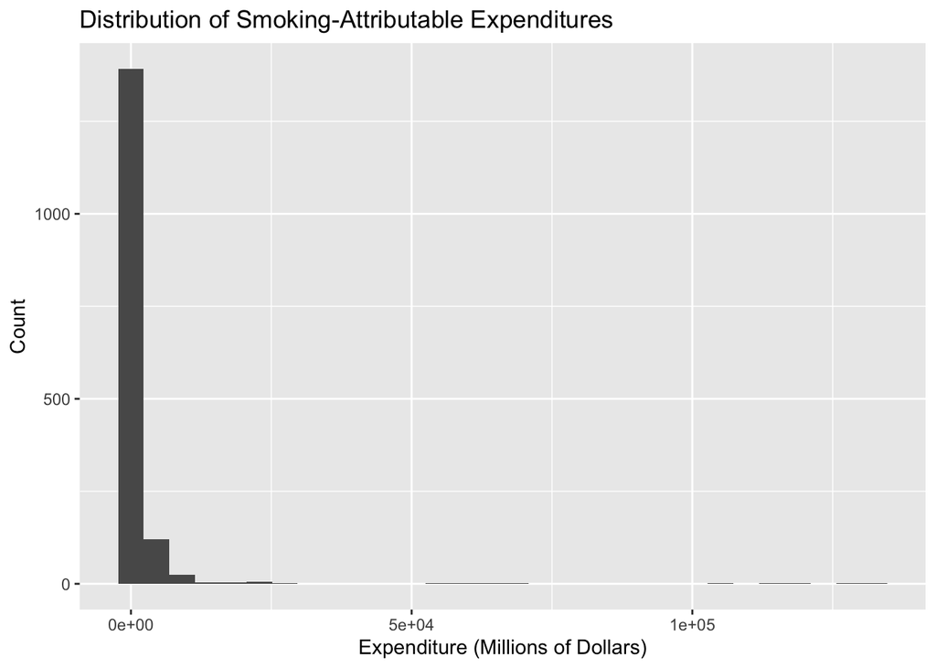

```r
## Histogram showing expenditure
ggplot(sae, aes(x = Data_Value)) +
  geom_histogram(bins = 30) +
    labs(title = "Distribution of Smoking-Attributable Expenditures",
        x = "Expenditure (Millions of Dollars)",
        y = "Count")
```

```r
mean_value <- mean(sae$Data_Value, na.rm = TRUE)
sd_value   <- sd(sae$Data_Value, na.rm = TRUE)

mean_value
```

```
[1] 1545.223
```

```r
sd_value
```

```
[1] 7868.553
```

```r
summary(sae$Data_Value)
```

```
    Min.  1st Qu.   Median     Mean  3rd Qu.     Max.
     8.4    105.7    306.1   1545.2    842.3 132459.8
```

The distribution of smoking-attributable expenditures is skewed to the right. Most values show low expenditure levels, while a few observations show large values. The mean will probably be inflated due to the large values.

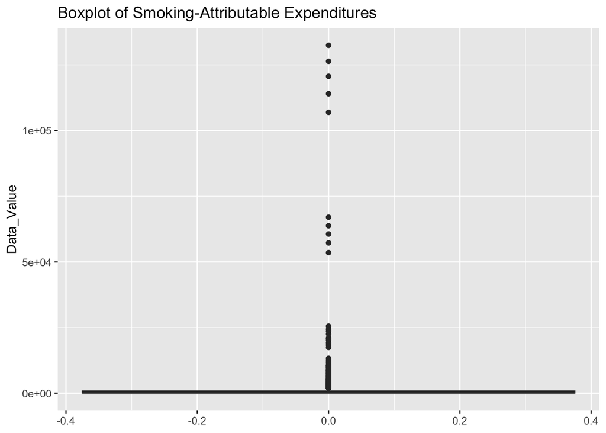

```r
##Boxplot
ggplot(sae, aes(y = Data_Value)) +
  geom_boxplot() +
  labs(title = "Boxplot of Smoking-Attributable Expenditures")
```

The boxplot of smoking-attributable expenditures is skewed to the right, with most of the observations having low values, while a few observations have large numbers. The large numbers in the data set increase variability.

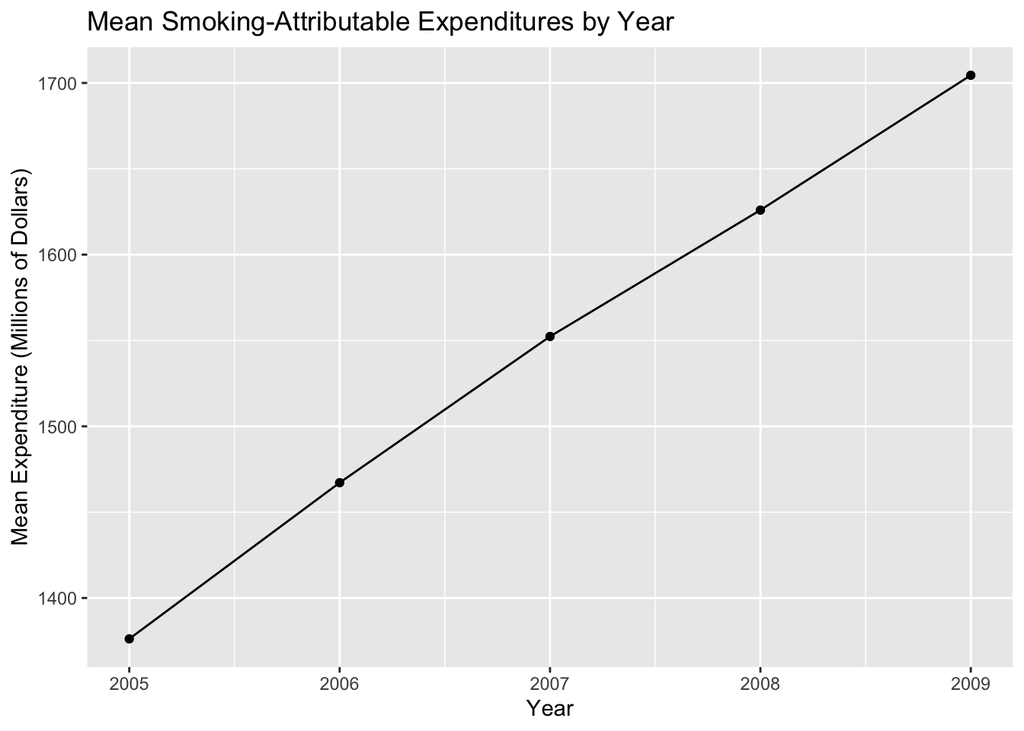

```r
##Distribution by year
sae %>%
  group_by(Year) %>%
  summarise(mean_expenditure = mean(Data_Value, na.rm = TRUE)) %>%
  ggplot(aes(x = Year, y = mean_expenditure)) + geom_line() + geom_point() +
  labs(title = "Mean Smoking-Attributable Expenditures by Year",
       x = "Year",
       y = "Mean Expenditure (Millions of Dollars)")
```

The mean smoking-attributable expenditures increased from 2005 to 2009, showing a positive linear trend over time. There is a consistent upward trend in smoking-related healthcare costs from 2005-2009.

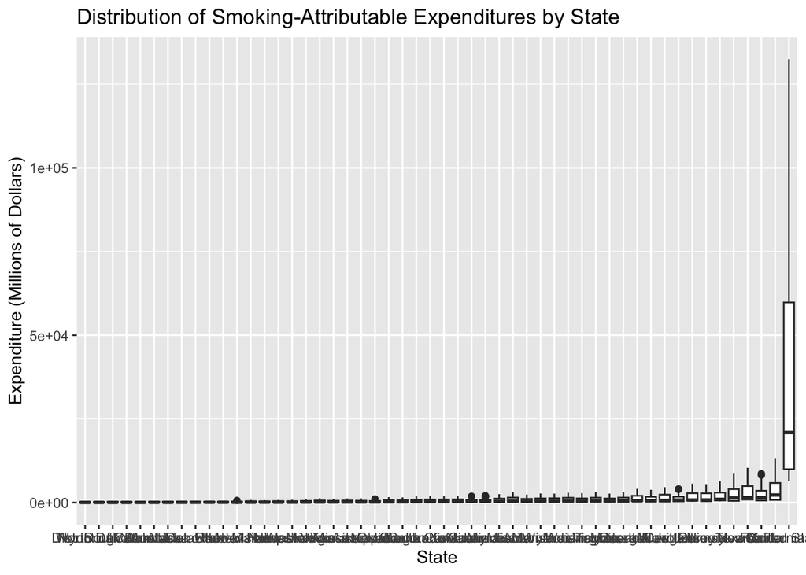

```r
##Distribution by state
ggplot(sae, aes(x = reorder(LocationDesc, Data_Value, median),
                y = Data_Value)) + geom_boxplot() +
  labs(title = "Distribution of Smoking-Attributable Expenditures by State",
       x = "State",
       y = "Expenditure (Millions of Dollars)")
```

The boxplot shows a lot of variability in smoking-attributable expenditures across states. Most states have low expenditure values, while a few states have higher expenditure values, which is why the boxplot is skewed to the right. The differences across states could be because of geographic and population factors.

## Synthetic data (This section contributed by Cassie Cui)

```r
# AI Assistance:
# I used an LLM to help draft general R code for generating a synthetic dataset with the same column structure as the cleaned data. I described the # panel structure (Year, Location, expense category) and that the outcome variable was right-skewed.

library(dplyr)
library(lubridate)

set.seed(123)

# Define number of rows to generate (match the cleaned data)
n_obs <- nrow(sae)


syn_dat <- data.frame(
  Year            = integer(n_obs),
  LocationAbbr    = character(n_obs),
  LocationDesc    = character(n_obs),
  Variable        = character(n_obs),
  TopicDesc       = character(n_obs),
  MeasureDesc     = character(n_obs),
  Data_Value      = numeric(n_obs),
  Data_Value_Type = character(n_obs),
  Data_Value_Unit = character(n_obs),
  stringsAsFactors = FALSE
)
# Year
year_levels <- sort(unique(sae$Year))
year_prob <- as.numeric(prop.table(table(sae$Year)))
syn_dat$Year <- sample(year_levels, size = n_obs, replace = TRUE, prob = year_prob)

# LocationAbbr
loc_levels <- unique(sae$LocationAbbr)
loc_prob <- as.numeric(prop.table(table(sae$LocationAbbr)))
syn_dat$LocationAbbr <- sample(loc_levels, size = n_obs, replace = TRUE, prob = loc_prob)

# Map Abbr -> Desc (lookup, no join)
loc_tbl <- sae %>% select(LocationAbbr, LocationDesc) %>% distinct()
syn_dat$LocationDesc <- loc_tbl$LocationDesc[match(syn_dat$LocationAbbr, loc_tbl$LocationAbbr)]

# Variable
var_levels <- unique(as.character(sae$Variable))
var_prob <- as.numeric(prop.table(table(as.character(sae$Variable))))
syn_dat$Variable <- sample(var_levels, size = n_obs, replace = TRUE, prob = var_prob)

# Fill label/metadata columns
syn_dat$TopicDesc <- if ("TopicDesc" %in% names(sae)) {
  sae$TopicDesc[which(!is.na(sae$TopicDesc))[1]]
} else "Smoking-Attributable Expenditures (SAEs)"

syn_dat$MeasureDesc <- if ("MeasureDesc" %in% names(sae)) {
  sae$MeasureDesc[which(!is.na(sae$MeasureDesc))[1]]
} else "Type of Expense"

syn_dat$Data_Value_Type <- if ("Data_Value_Type" %in% names(sae)) {
  sae$Data_Value_Type[which(!is.na(sae$Data_Value_Type))[1]]
} else "Millions of Dollars"

syn_dat$Data_Value_Unit <- if ("Data_Value_Unit" %in% names(sae)) {
  sae$Data_Value_Unit[which(!is.na(sae$Data_Value_Unit))[1]]
} else "$"

# Generate synthetic Data_Value (right-skewed) by Variable
syn_dat$Data_Value <- NA_real_
vars <- unique(var_levels)



for (v in vars) {
  idx <- syn_dat$Variable == v

  x <- sae$Data_Value[as.character(sae$Variable) == v]
  x <- x[is.finite(x) & !is.na(x)]
  x <- pmax(x, 1e-6)  # guard against zeros

  meanlog_v <- mean(log(x))
  sdlog_v   <- sd(log(x))

  syn_dat$Data_Value[idx] <- round(rlnorm(sum(idx), meanlog = meanlog_v, sdlog = sdlog_v), 1)
}

dim(syn_dat)
```

```
[1] 1560    9
```

```r
head(syn_dat)
```

```
  Year LocationAbbr LocationDesc           Variable
1 2007           KY     Kentucky Prescription Drugs
2 2009           CO     Colorado         Ambulatory
3 2008           MN    Minnesota              Other
4 2005           ND North Dakota              Other
5 2005           ID        Idaho           Hospital
6 2006           NV       Nevada              Other
                                 TopicDesc     MeasureDesc Data_Value
1 Smoking-Attributable Expenditures (SAEs) Type of Expense     1284.8
2 Smoking-Attributable Expenditures (SAEs) Type of Expense      202.8
3 Smoking-Attributable Expenditures (SAEs) Type of Expense       50.1
4 Smoking-Attributable Expenditures (SAEs) Type of Expense       49.4
5 Smoking-Attributable Expenditures (SAEs) Type of Expense      453.1
6 Smoking-Attributable Expenditures (SAEs) Type of Expense       16.6
      Data_Value_Type Data_Value_Unit
1 Millions of Dollars               $
2 Millions of Dollars               $
3 Millions of Dollars               $
4 Millions of Dollars               $
5 Millions of Dollars               $
6 Millions of Dollars               $
```

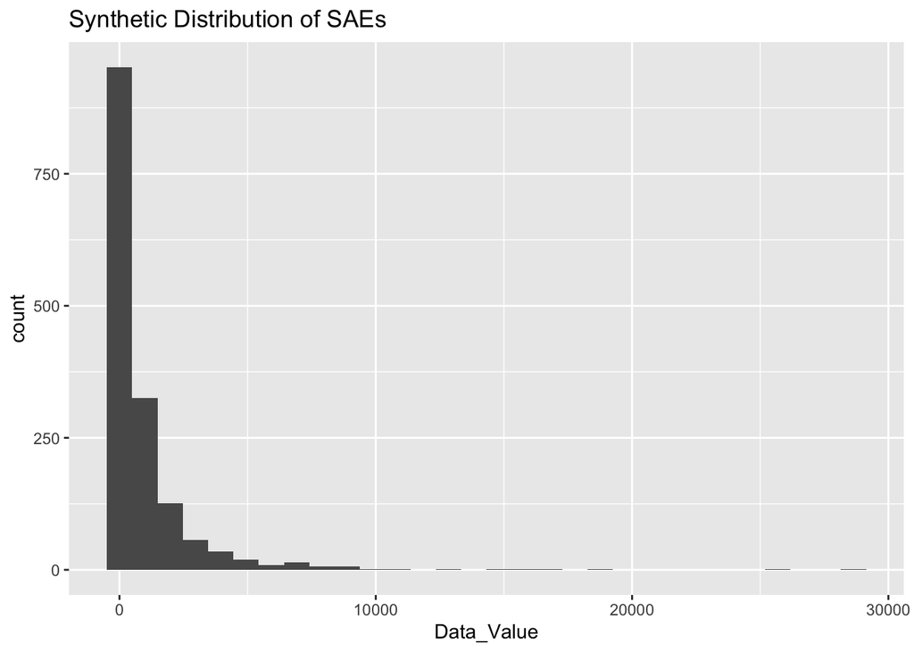

```r
ggplot(syn_dat, aes(x = Data_Value)) +
  geom_histogram(bins = 30) +
  labs(title = "Synthetic Distribution of SAEs")
```

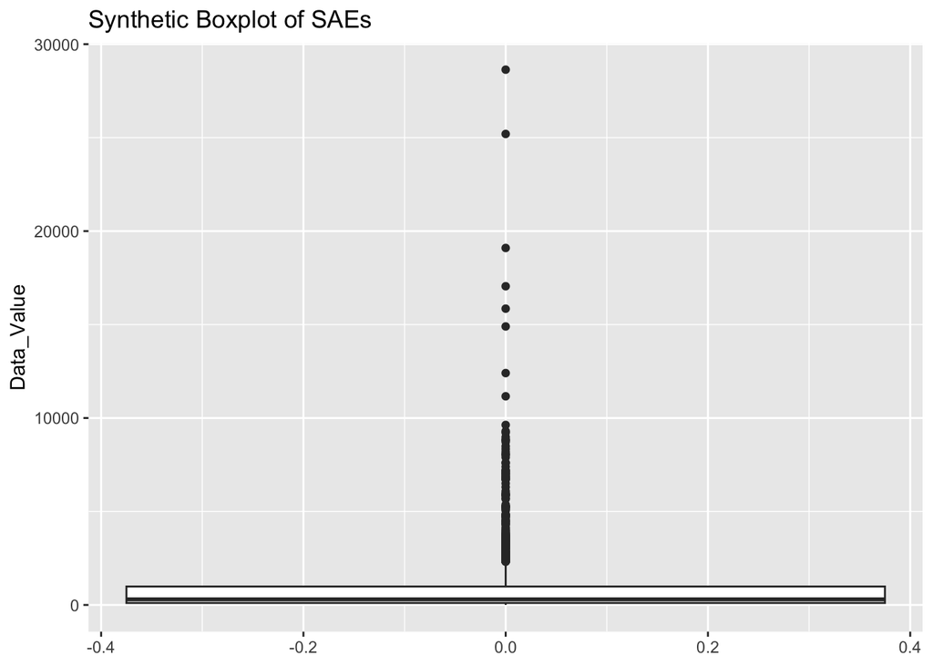

```r
ggplot(syn_dat, aes(y = Data_Value)) +
  geom_boxplot() +
  labs(title = "Synthetic Boxplot of SAEs")
```

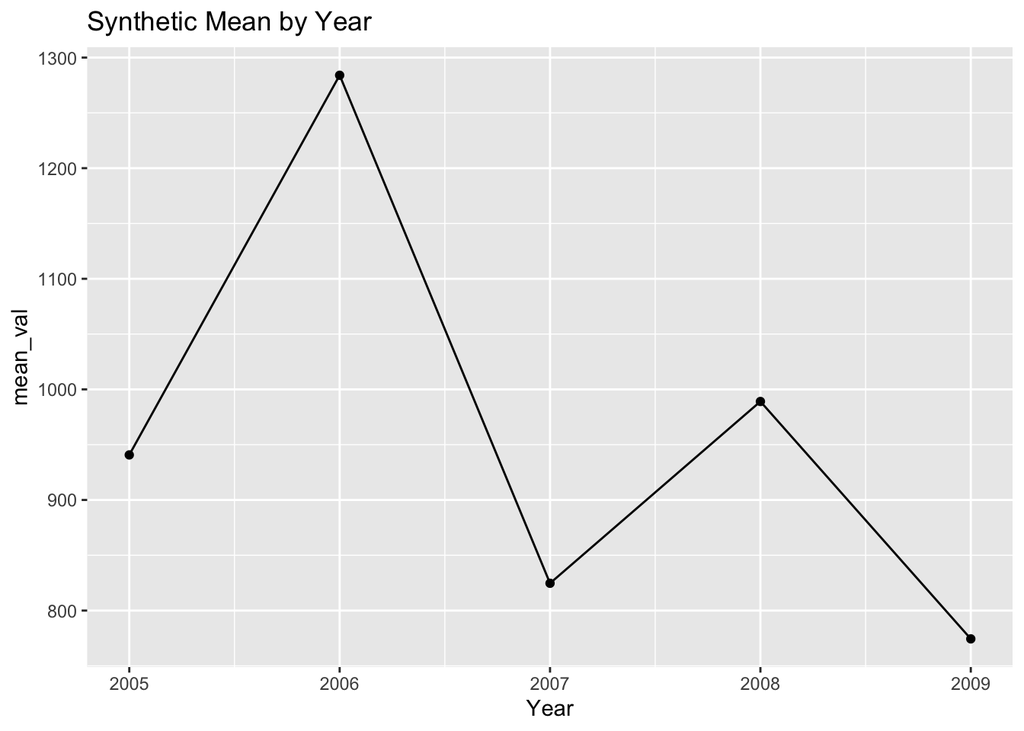

```r
syn_dat %>%
  group_by(Year) %>%
  summarise(mean_val = mean(Data_Value)) %>%
  ggplot(aes(x = Year, y = mean_val)) +
  geom_line() +
  geom_point() +
  labs(title = "Synthetic Mean by Year")
```

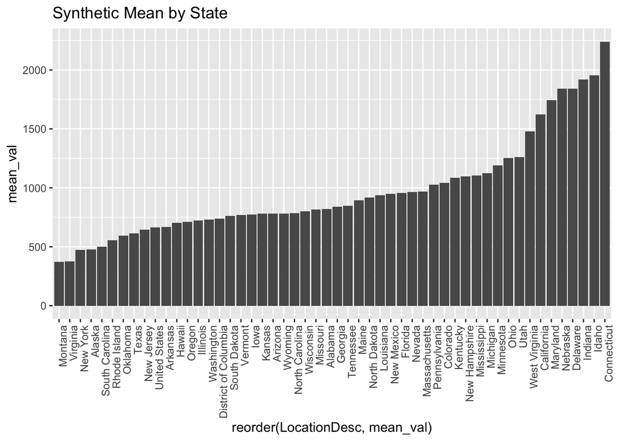

```r
syn_dat %>%
  group_by(LocationDesc) %>%
  summarise(mean_val = mean(Data_Value)) %>%
  ggplot(aes(x = reorder(LocationDesc, mean_val), y = mean_val)) +
  geom_col() +
  theme(axis.text.x = element_text(angle = 90, hjust = 1)) +
  labs(title = "Synthetic Mean by State")
```

The synthetic dataset preserves the same panel structure and the overall right-skewed distribution of Data_Value. Because values were simulated independently (within expense categories), the year-to-year mean trend is not forced to match the original increasing pattern, so some fluctuations are expected.

The synthetic data preserves the marginal distributions of Year, Location, and expense category, as well as the overall right-skewed pattern of expenditures. However, because state-level effects were not explicitly modeled, the ranking and spread of mean expenditures across states differ from the original dataset. This reflects the independence assumptions in the simulation.